# Survival Analysis in R - Part 3

Source: https://www.emilyzabor.com/survival-analysis-in-r.html

```
library(knitr)
library(dplyr)
library(survival)
library(ggplot2)
library(tibble)
library(lubridate)
library(ggsurvfit)
library(tidycmprsk)
library(gtsummary)


ezfun::set_ccf_palette("contrast")
```

# Part 3 Competing Risks

1. Competing risks analyses may be used when subjects have multiple possible events in a time-to-event setting.
1. Examples: 1) Recurrence. 2) Death from disease. 3) Death from other causes. 4) Treatment response.
2. All or some of these examples (among others) may be possible events in any given study.
2. Fundamental Problem in Competing Risks: unobserved dependence among the various event times.
1. Example: patients who recur are more likely to die, and therefore times to recurrence and times to death would NOT be independent events.
3. Two Approaches in Competing Risks Analyses:
1. **Cause-Specific Hazard of a Given Event**: represents the rate per unit of time of the event among those not having failed from other events. 1) When the events are independent (almost never true), cause-specific hazards is **unbiased**. 2) When the events are dependent, a variety of results can be obtained depending on the setting. 3) Cause-specific hazards is preferred when: the goal is to establish that a covariate is indeed acting on the event of interest, cause-specific hazards may be preferred for treatment or prognostic marker effect testing. 4) Obtain the cause-specific hazard of a given event is done by:
   1. Defining the event of interest as an event.
   2. Defining any competing events as censored at the date of the competing event.
2. **Subdistribution Hazard of a Given Event**: represents the rate per unit time of the event as well as the influencing of competing events. 1) Cumulative incidence using 1 - Kaplan Meier Estimate always $\geq$ Cumulative incidence using competing risk methods.
   1. Using Kaplan-Meier estimate when there is competing risks $\rightarrow$ overestimate of the cumulative incidence.
   1. The amount of overestimation depends on event rates and dependence among events. 2) Subdistribution hazards is preferred when: the goal is to establish overall benefit, subdistribtution hazards may be preferred for buidling prognostic nomograms or considering health economic effects to get a better sense of the influence of treatment and other covariates on an absolute scale.
4. Each of the two approaches may only illustrate one important aspect of the data while possibly obscuring others.
1. Thus, the chosen approach should depend on the question of interest.

## Subdistribution Hazards:

1. R package for competing risk analysis: {tidycmprsk}.
2. Example: The `Melanoma` Dataset
1. `Melanoma` data comes from the {MASS} package.
2. `Melanoma` contains variables: 1) `time`: survival time in days, possibly censored. 2) `status`: 1 died from melanoma, 2 alive, 3 dead from other causes. 3) `sex`: 1 = male, 0 = female. 4) `age`: age in years. 5) `year`: year of operation. 6) `thickness`: tumor thickness in mm. 7) `ulcer`: 1 = presence, 0 = absence.

|  | time | status | sex | age | year | thickness | ulcer |
| --- | --- | --- | --- | --- | --- | --- | --- |
| 1 | 10 | 3 | 1 | 76 | 1972 | 6.76 | 1 |
| 2 | 30 | 3 | 1 | 56 | 1968 | 0.65 | 0 |
| 3 | 35 | 2 | 1 | 41 | 1977 | 1.34 | 0 |
| 4 | 99 | 3 | 0 | 71 | 1968 | 2.90 | 0 |
| 5 | 185 | 1 | 1 | 52 | 1965 | 12.08 | 1 |
| 6 | 204 | 1 | 1 | 28 | 1971 | 4.84 | 1 |

The `status` variable in these data are coded in a non-standard way. We will recode the variable so that we have: status = 0 is alive, status = 1 is died from melanoma, status = 2 is died from other causes.

```
Melanoma <- Melanoma %>% mutate(
  status = as.factor(recode(status, `2` = 0, `1` = 1, `3` = 2))
)

head(Melanoma)
```

|  | time | status | sex | age | year | thickness | ulcer |
| --- | --- | --- | --- | --- | --- | --- | --- |
| 1 | 10 | 2 | 1 | 76 | 1972 | 6.76 | 1 |
| 2 | 30 | 2 | 1 | 56 | 1968 | 0.65 | 0 |
| 3 | 35 | 0 | 1 | 41 | 1977 | 1.34 | 0 |
| 4 | 99 | 2 | 0 | 71 | 1968 | 2.90 | 0 |
| 5 | 185 | 1 | 1 | 52 | 1965 | 12.08 | 1 |
| 6 | 204 | 1 | 1 | 28 | 1971 | 4.84 | 1 |

### Cumulative Incidence for Competing Risks

1. Nonparametric Estimate of the Cumulative Incidence of the Event of Interest: at any point in time, the sum of the cumulative incidence of each event is equal to the total cumulative incidence of any event (not true in the cause-specific setting).
2. Gray’s test is a modified Chi-squared test used to compare 2 or more groups.
3. Estimate the cumulative incidence in the context of competing risks using the `cuminc` function from the {tidycmprsk} package.
1. By default, the status variable has to be a factor with censored patients coded as 0.

```
# Surv() ~ 1: means no grouping variable so the function will compute the overall cumulative incidence functions for each event type in the dataset, not separated by treatment or groups. ## ~1 produce CIF curves for the entire sample (one group).
## Analogous to survfit(Surv(time, status) ~ 1): gives one Kaplan-Meier curve for everyone.
## Surv() ~ treatment: separate cumulative incidence curves for each event type within each treatment group.
### Conduct Gray's test for comparing CIFs between groups.
### This is used when you want to compare cumulative incidence between groups.
cuminc(Surv(time, status) ~ 1, data = Melanoma)
```

```
── cuminc() ────────────────────────────────────────────────────────────────────────────

• Failure type "1"
time    n.risk   estimate   std.error   95% CI
1,000   171      0.127      0.023       0.086, 0.177
2,000   103      0.230      0.030       0.174, 0.291
3,000   54       0.310      0.037       0.239, 0.383
4,000   13       0.339      0.041       0.260, 0.419
5,000   1        0.339      0.041       0.260, 0.419

• Failure type "2"
time    n.risk   estimate   std.error   95% CI
1,000   171      0.034      0.013       0.015, 0.066
2,000   103      0.050      0.016       0.026, 0.087
3,000   54       0.058      0.017       0.030, 0.099
4,000   13       0.106      0.032       0.053, 0.179
5,000   1        0.106      0.032       0.053, 0.179
```

4. Use the `ggcumnin()` function from the {ggsurvfit} package to plot the cumulative incidence.
1. By default, it plots the first event type only.
2. The following plot shows the cumulative incidence of death from melanoma (status = 1: death from melanoma).

```
cuminc(Surv(time, status) ~ 1, data = Melanoma) %>%
  ggcuminc() +
  labs(
    x = "Days"
  ) +
  add_confidence_interval() +
  add_risktable()
```

```
Plotting outcome "1".
```

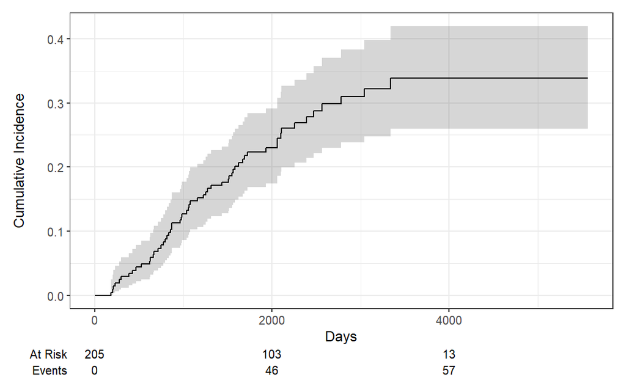

3. If you want to include both event types, specify the outcomes in the `ggcuminc(outcome =)` argument:

```
cuminc(Surv(time, status) ~ 1, data = Melanoma) %>%
  # Ask to include both event 1 (death from melanoma) and 2 (death from other causes).
  ggcuminc(outcome = c("1", "2")) +
  ylim(c(0, 1)) +
  labs(
    x = "Days"
  )
```

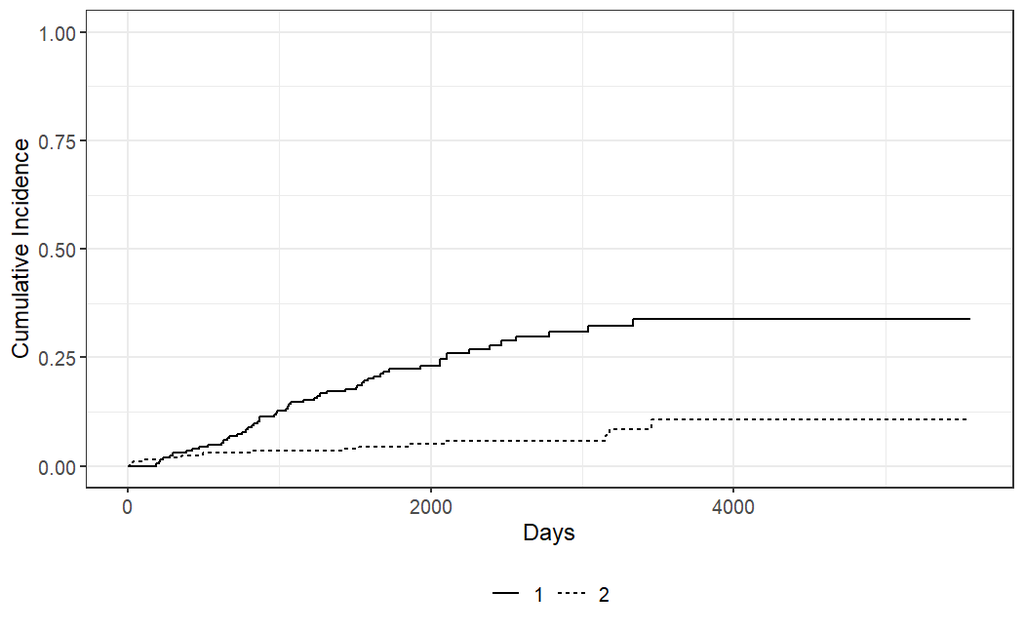

5. Analyze death from melanoma or other causes in the Melanoma data, according to the presence or absence of ulceration.
1. We can estimate the cumulative incidence at various times by group and display that in a table using the `tbl_cuminc()` function from the {tidycmprsk} package.
2. Gray’s test can be added to test for a difference between groups over the entire follow up period using the `add_p()` function.

```
cuminc(Surv(time, status) ~ ulcer, data = Melanoma) %>%
  tbl_cuminc(
    times = 1826.25, # Number of days in 5 years.
    label_header = "**{time / 365.25}-year cuminc"
  )
```

| **Characteristic** | **5-year cuminc |
| --- | --- |
| ulcer |  |
| 0 | 9.1% (4.6%, 15%) |
| 1 | 39% (29%, 49%) |

3. Plot death due to melanoma according to ulceration status using `ggcuminc()` from the {ggsurvfit} package.

```
cuminc(Surv(time, status) ~ ulcer, data = Melanoma) %>%
  ggcuminc() +
  labs(
    x = "Days"
  ) +
  add_confidence_interval() +
  add_risktable()
```

```
Plotting outcome "1".
```

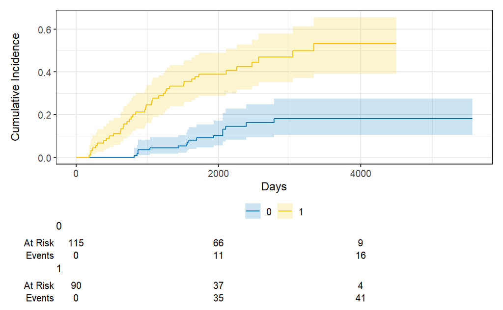

### Competing Risks Regression

1. Two Approaches to Competing Risks Regression:
1. Cause-specific Hazards: 1) Instantaneous rate of occurence of the given type of event in subjects who are currently event-free. 2) Estimated using Cox regression (`coxph` function).
2. Subdistribution Hazards: 1) Instantaneous rate of occurence of the given type of event in subjects who have not yet experienced an event of that type. 2) Estimated using Fine-Gray regression (`crr` function).
2. **Example 1 - Subdistribution Hazards**: Finding out the effect of age and sex on death from melanoma, with death from other causes as a competing event.
1. The `crr()` function from the {tidycmprsk} package will estimate the subdistribution hazards.

```
crr(Surv(time, status) ~ sex + age, data = Melanoma)
```

```
── crr() ───────────────────────────────────────────────────────────────────────────────
• Call Surv(time, status) ~ sex + age
• Failure type of interest "1"

Variable   Coef    SE      HR     95% CI       p-value
sex        0.588   0.272   1.80   1.06, 3.07   0.030
age        0.013   0.009   1.01   0.99, 1.03   0.18
```

2. Generate tables of formatted results using the `tbl_regression()` function from the {gt_summary} package. 1) The option `exp = TRUE` allows you to obtain the hazard ratio estimates.

```
crr(Surv(time, status) ~ sex + age, data = Melanoma) %>%
  tbl_regression()
```

| **Characteristic** | **log(HR)** | **95% CI** | **p-value** |
| --- | --- | --- | --- |
| sex | 0.59 | 0.06, 1.1 | 0.030 |
| age | 0.01 | -0.01, 0.03 | 0.2 |

Abbreviations: CI = Confidence Interval, HR = Hazard Ratio

3. Male sex (1 = male, 0 = female) is significantly associated with increased hazard of death due to melanoma (p-value = 0.03).
4. Age was NOT significantly associated with death due to melanoma (p-value = 0.2).
3. **Example 2 - Cause-specific Hazards**: Finding out the effect of age and sex on death from melanoma, with death from other causes as a competing event.
1. If we use the cause-specific hazards regression approach, we first need to censor all subjects who did NOT have the event of interest (i.e. death from melanoma). Then use the `coxph` as before.

```
1) Patients who died from other causes are now censored for the cause-specific hazard approach to competing risk.
```

```
coxph(
  Surv(time, ifelse(status == 1, 1, 0)) ~ age + sex, data = Melanoma

) %>%
  tbl_regression(exp = TRUE)
```

| **Characteristic** | **HR** | **95% CI** | **p-value** |
| --- | --- | --- | --- |
| age | 1.02 | 1.00, 1.03 | 0.056 |
| sex | 1.82 | 1.08, 3.07 | 0.025 |

Abbreviations: CI = Confidence Interval, HR = Hazard Ratio

2. Male sex (1 = male, 0 = female) is significantly associated with increased hazard of death due to melanoma (p-value = 0.025).
3. Age was NOT significantly associated with death due to melanoma (p-value = 0.056).